# Blockchain

Eigendom vastleggen in het Bitcoin netwerk

Bèr `berkes` Kessels

# Over Bèr Kessels

- Bèr Kessels
- https://{twitter.com,reddit.com/u,linkedin.com/in}/berkes
- Oprichter PlaceBazaar

# Over mij en Blockchain (Full Disclosure)

- April 2011 begonnen met Bitcoin
- Heeft portfolio met technisch interessante Crypto-assets
  - Bitcoin, Ethereum, Stellar, en diverse ICO tokens
- Oprichter van een crypto startup

# PlaceBazaar - Crypto startup

> Een platform waar mensen betaald worden voor bijdragen aan een Open Source kaart-database: van het toevoegen van flitspalen tot het verifiëren van de openingstijden van een camping. De betaler is een partij die deze data nodig heeft, zoals een routeplanner, toerismebureau, verzekeraar, of campingvergelijker.

# Over de presentatie

- Staat op berk.es/blockchainpres
- Bron: git.webschuur.com/berkes/blockchainpres
- URL komt aan het eind voorbij

# Inhoud

- Bitcoin en Blockchain
- Smart Contracts
- Toepassingen
- De Hype

# Wat is Blockchain?

Een onveranderlijk, gedistribueerd grootboek

*An Immutable, Distributed Ledger*

# Wat bedoelen we met een grootboek?

Een database met daarin informatie als saldi, eigendomsbewijzen, smart contract status.

# Ledgers: een blok

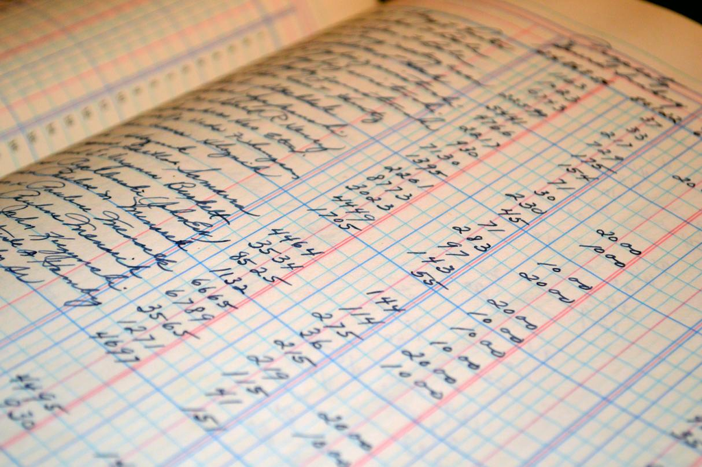

# Recursion

[figure not shown]

# Recursion

- Blok 1 = transacties + reward
- Samenvatting Blok 1 = B1
- Blok 2 = B1 + transacties + reward
- Samenvatting Blok 2 = B2
- Blok 3 = B2 + transacties + reward

# Gedistribueerd?

- Anne stuurt geld naar persoon Bob
- Anne maakt hiervoor een transactie aan en stuurt deze naar haar server S
- Server S stuurt het naar andere leden op het netwerk. Die sturen het weer door etc.
- Alle leden verifiëren de informatie
- Iedereen valideert de informatie
- Geen activiteit zonder permissie van de leden
- Indien geen bezwaren, wordt de transactie toegepast

# Waarom Gedistribueerd?

- Geen centraal "point of failure"
- Kan wereldwijd opschalen
- Trustless, Uncensorable, Permissionless

# Onveranderlijk? (Immutable)

- Data kan niet aangepast worden nadat het in het grootboek is weggeschreven
- Data is controleerbaar
- Er is consensus nodig om het grootboek bij te werken

# Wat is consensus?

- "Iedereen" komt overeen wat de huidige status is
  - Bijvoorbeeld: wat zijn de saldi van iedereens rekeningen

# Hoe komen we tot consensus?

- Consensus algoritmes
  - Proof of work, Proof of stake

# Andere Soorten Ledgers

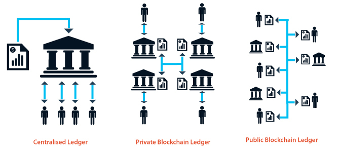

# Problemen: Code is Law

*The DAO "hack"*

Was het een Hack, een bug, of letterlijke opvolging van een contract?

Zie ook [The Truth about Smart Contracts](https://medium.com/@jimmysong/the-truth-about-smart-contracts-ae825271811f)

# Problemen: Oracle

*Er is geen link tussen de fisieke wereld en de digitale*

Blockchains weten niets over de omgeving.

De boom met een wallet: Is hij écht gesnoeid? Moet hij water krijgen?

# Problemen: Realiteit

[figure not shown]

Terence Eden claims he made the Mona Lisa. Code is Law, right?

Van [Verisart](https://www.verisart.com/works/23f2c64a-08c6-4a42-8013-84ac8422dffb)

# Heb je een Blockchain nodig?

# Carnaval in Breda

[figure not shown]

# Dit is Centraal

[figure not shown]

# Heb je een Blockchain nodig?

# Wereldwijde carnavalsmunten?

- Wereldwijd te gebruiken
- Onderling te verhandelen (Eenmalige uitgave gegarandeerd)
- Kleine handelaren (Iedereen kan ontvangen)
- Onafhankelijk, Decentraal, Permissionless

# Heb je een Blockchain nodig?

Yes

# PlaceBazaar

- Bijdragen: Permissionless
- Uitlezen: Permissionless
- Betalingen: Zonder derden

# Presentatie

- berk.es/blockchainpres